# Hypothesis Testing for Causal Effects

Se Yoon Lee

2026-07-06

## 1 Today’s Question

Lectures 1-6 built one causal analysis in stages.

| Lecture | Main idea | How this note uses it |
| --- | --- | --- |
| Lecture 1 | Simple observed risk difference | Start with the crude association |
| Lecture 2 | Inverse probability weighting | Test an IPW-adjusted risk difference |
| Lecture 3 | Outcome regression standardization | Test a standardized risk difference |
| Lecture 4 | Doubly robust estimation | Test a doubly robust risk difference |
| Lecture 5 | Bootstrap confidence intervals | Use the bootstrap to estimate uncertainty |
| Lecture 6 | E-values and sensitivity analysis | Keep statistical evidence separate from causal-validity evidence |

The new question is:

> Once we have a risk-difference estimate, how much statistical evidence is there against no difference?

The causal question stays the same:

$$\text{Is CVD risk different under smoking versus non-smoking?}$$

The target causal risk difference is

$$RD = E\{Y(1)\} - E\{Y(0)\}.$$

Here $Y(1)$ is the potential CVD outcome under smoking and $Y(0)$ is the potential CVD outcome under non-smoking.

We will again use the classroom NHANES complete-case dataset from Lectures 1-6 and we will again **not use survey weights**. The goal is to understand causal estimands, uncertainty, and hypothesis testing in the same teaching example, not to produce a full NHANES survey analysis.

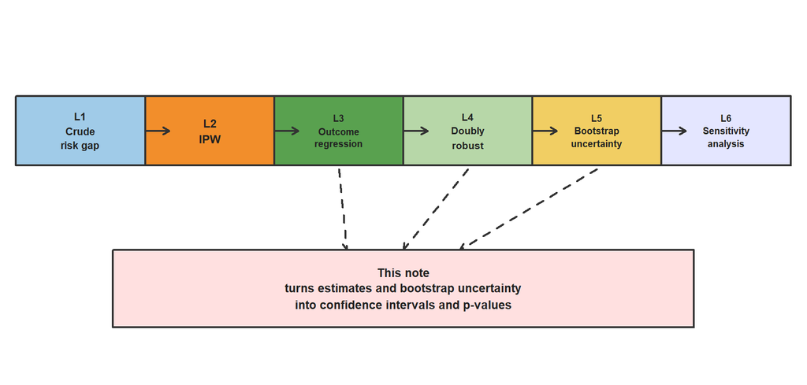

## 2 What Hypothesis Testing Adds

Hypothesis testing does not create a causal estimand and it does not make confounding disappear.

It answers a narrower statistical question:

> If the true target contrast were equal to a chosen null value, would our estimate look unusually far away from that value?

| Layer | Question | Main lectures |
| --- | --- | --- |
| Causal question | What would happen under smoking versus non-smoking? | Lecture 1 |
| Identification and estimation | How do we estimate $E\{Y(1)\}$ and $E\{Y(0)\}$? | Lectures 2-4 |
| Statistical uncertainty | How variable is the estimate across samples? | Lecture 5 and this note |
| Causal-validity uncertainty | How sensitive is the answer to unmeasured confounding? | Lecture 6 |

So a p-value belongs to the statistical uncertainty layer. A p-value can be small even when the causal assumptions are wrong. A p-value can also be large even when an effect exists but the data are noisy.

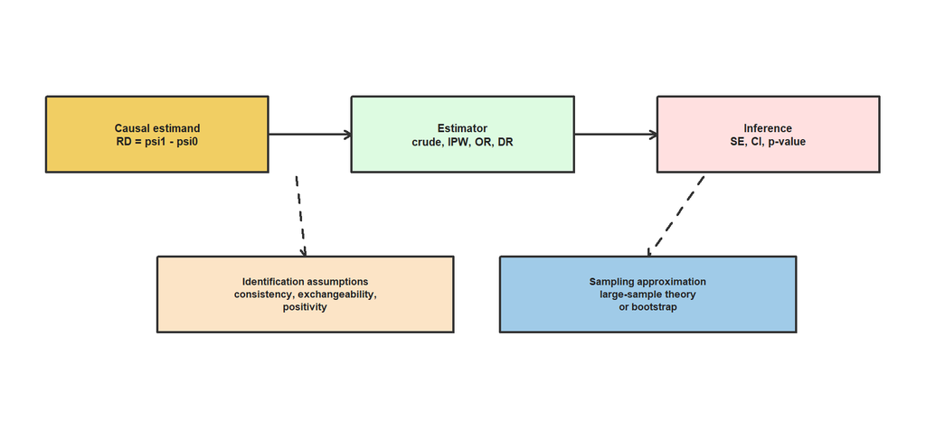

## 3 The Null Hypothesis

For the risk difference, the most common point null hypothesis is

$$H_0: RD = 0.$$

The two-sided alternative is

$$H_A: RD \neq 0.$$

In words, the null says that the marginal CVD risk under smoking equals the marginal CVD risk under non-smoking:

$$E\{Y(1)\} = E\{Y(0)\}.$$

The same idea can be written on other effect scales. For a risk ratio, the no-effect null is

$$H_0:
\frac{E\{Y(1)\}}{E\{Y(0)\}} = 1.$$

For a log risk ratio, the same null is

$$H_0:
\log\left(
\frac{E\{Y(1)\}}{E\{Y(0)\}}
\right) = 0.$$

This note focuses on the risk difference because Lectures 1-5 used risk differences as the main classroom contrast.

## 4 Wald Tests

Suppose an estimator satisfies the large-sample approximation

$$\hat\theta \approx N(\theta, SE^2).$$

Here $\theta$ is a generic estimand. In our main analysis, $\theta$ will be the risk difference $RD$. To test $H_0: \theta = \theta_0$, the Wald statistic is

$$Z
=
\frac{\hat\theta - \theta_0}{\widehat{SE}(\hat\theta)}.$$

Under the null hypothesis and regularity conditions,

$$Z \approx N(0,1).$$

The two-sided p-value is

$$p
=
2\{1 - \Phi(|Z_{\mathrm{obs}}|)\}.$$

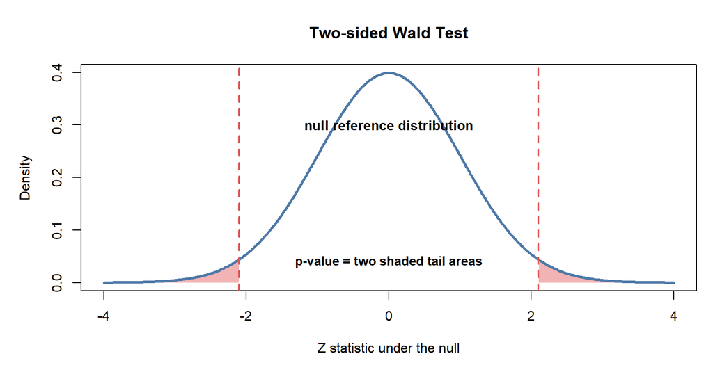

The p-value is not $P(H_0 \mid \text{data})$. It is the probability, computed under the null reference distribution, of obtaining a test statistic at least as extreme as the one observed.

## 5 Confidence Intervals and Tests

For a two-sided 5 percent Wald test, the null value $\theta_0$ is rejected when

$$\left|
\frac{\hat\theta - \theta_0}
{\widehat{SE}(\hat\theta)}
\right|
> 1.96.$$

Equivalently, $\theta_0$ is rejected if it lies outside the 95 percent Wald confidence interval

$$\hat\theta \pm 1.96 \widehat{SE}(\hat\theta).$$

Bootstrap percentile intervals use a different construction, but the teaching interpretation is similar: if the 95 percent interval for the risk difference excludes zero, the data are not very compatible with $RD=0$ under the assumptions behind the analysis.

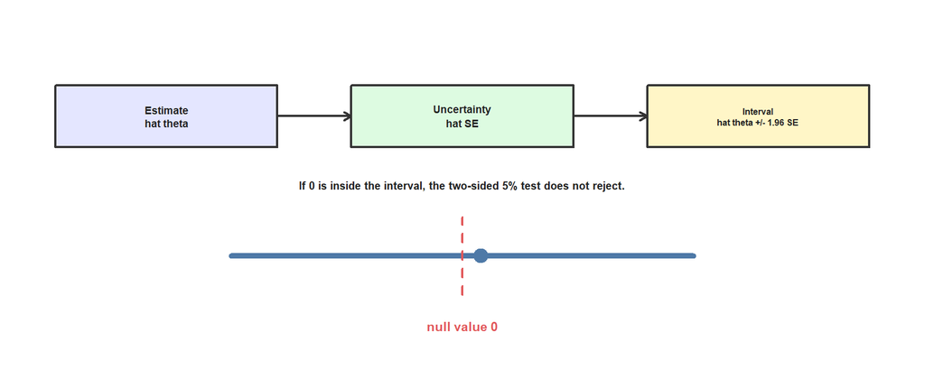

Confidence intervals are often more informative than p-values because they show the direction and magnitude of the estimated effect.

## 6 Load and Prepare the Data

We use the same classroom NHANES complete-case analytic sample as the previous lectures.

```r
data_candidates <- c(
  file.path("..", "Data", "NHANES_data.csv"),
  file.path("Data", "NHANES_data.csv"),
  "C:/Users/seyoo/OneDrive/GitHub_repository/Causal_Inference_Survival_Analysis/Causal_Inference_Lecture/Data/NHANES_data.csv"
)

data_path <- data_candidates[file.exists(data_candidates)][1]
if (is.na(data_path)) {
  stop("Could not find NHANES_data.csv. Check the data path.")
}

nhanes <- read.csv(data_path, stringsAsFactors = FALSE)

baseline_vars <- c(
  "age_yr",
  "gender",
  "race",
  "educ_lvl",
  "inc_to_pov_ratio",
  "bmi"
)

analysis_vars <- c("smoker_indicator", "cvd_indicator", baseline_vars)

ht_data <- nhanes[complete.cases(nhanes[, analysis_vars]), analysis_vars]
ht_data$smoker_indicator <- as.integer(ht_data$smoker_indicator)
ht_data$cvd_indicator <- as.integer(ht_data$cvd_indicator)

ht_data$smoking_group <- factor(
  ifelse(ht_data$smoker_indicator == 1, "Smoker", "Non-smoker"),
  levels = c("Non-smoker", "Smoker")
)

ht_data$gender_label <- factor(
  ht_data$gender,
  levels = c("F", "M"),
  labels = c("Female", "Male")
)

ht_data$race_label <- factor(
  ht_data$race,
  levels = c(
    "mex_american",
    "other_hispanic",
    "nh_white",
    "nh_black",
    "nh_asian"
  ),
  labels = c(
    "Mexican American",
    "Other Hispanic",
    "Non-Hispanic White",
    "Non-Hispanic Black",
    "Non-Hispanic Asian"
  )
)

ht_data$educ_label <- factor(
  ht_data$educ_lvl,
  levels = c(
    "lt_9th_grade",
    "9_to_12th_grade_no_diploma",
    "hs_grad_or_ged",
    "start_college_to_aa",
    "college_grad_or_above"
  ),
  labels = c(
    "Less than 9th grade",
    "9th-12th, no diploma",
    "High school or GED",
    "Some college or AA",
    "College graduate or above"
  )
)

nrow(ht_data)
```

```
## [1] 6299
```

```r
sample_summary <- data.frame(
  Group = c("Non-smoker", "Smoker", "Total"),
  N = c(
    sum(ht_data$smoker_indicator == 0),
    sum(ht_data$smoker_indicator == 1),
    nrow(ht_data)
  ),
  CVD_percent = round(100 * c(
    mean(ht_data$cvd_indicator[ht_data$smoker_indicator == 0]),
    mean(ht_data$cvd_indicator[ht_data$smoker_indicator == 1]),
    mean(ht_data$cvd_indicator)
  ), 2)
)

knitr::kable(sample_summary)
```

| Group | N | CVD_percent |
| --- | --- | --- |
| Non-smoker | 3740 | 6.93 |
| Smoker | 2559 | 15.12 |
| Total | 6299 | 10.26 |

## 7 Rebuild the Lecture 1-4 Estimates

First we rebuild the point estimates from the earlier causal lectures.

```r
t1 <- ht_data$smoker_indicator == 1
t0 <- ht_data$smoker_indicator == 0

n1 <- sum(t1)
n0 <- sum(t0)
p1 <- mean(ht_data$cvd_indicator[t1])
p0 <- mean(ht_data$cvd_indicator[t0])

crude_estimates <- c(
  psi1 = p1,
  psi0 = p0,
  rd = p1 - p0,
  rr = p1 / p0
)

adjusted_estimates <- fit_course_estimators(ht_data)

all_estimates <- rbind(
  Observed_comparison = crude_estimates,
  adjusted_estimates
)

estimate_table <- data.frame(
  Lecture_connection = c(
    "Lecture 1",
    "Lecture 2",
    "Lecture 3",
    "Lecture 4"
  ),
  Method = c(
    "Observed comparison",
    "IPW",
    "Outcome regression",
    "Doubly robust"
  ),
  Non_smoker_risk_percent = round(100 * all_estimates[, "psi0"], 2),
  Smoker_risk_percent = round(100 * all_estimates[, "psi1"], 2),
  Risk_difference_pp = round(100 * all_estimates[, "rd"], 2),
  Risk_ratio = round(all_estimates[, "rr"], 3),
  row.names = NULL
)

knitr::kable(
  estimate_table,
  col.names = c(
    "Connection",
    "Method",
    "Non-smoker risk (%)",
    "Smoker risk (%)",
    "Risk difference (pp)",
    "Risk ratio"
  )
)
```

| Connection | Method | Non-smoker risk (%) | Smoker risk (%) | Risk difference (pp) | Risk ratio |
| --- | --- | --- | --- | --- | --- |
| Lecture 1 | Observed comparison | 6.93 | 15.12 | 8.20 | 2.184 |
| Lecture 2 | IPW | 8.71 | 11.70 | 2.99 | 1.343 |
| Lecture 3 | Outcome regression | 8.53 | 11.98 | 3.45 | 1.405 |
| Lecture 4 | Doubly robust | 8.56 | 11.82 | 3.25 | 1.380 |

Here `pp` means **percentage points**.

These four rows answer related but not identical questions:

1. The observed comparison is the raw association from Lecture 1.
2. IPW uses the treatment model from Lecture 2.
3. Outcome regression uses the standardization idea from Lecture 3.
4. The doubly robust estimator combines the treatment and outcome models from Lecture 4.

## 8 Simple Observed-Risk Test

For the Lecture 1 observed comparison, the usual two-sample standard error for a difference in proportions is

$$\widehat{SE}_{\mathrm{crude}}
=
\sqrt{
\frac{\hat p_1(1-\hat p_1)}{n_1}
+
\frac{\hat p_0(1-\hat p_0)}{n_0}
}.$$

This is an association test, not a fully adjusted causal test.

```r
rd_crude <- crude_estimates["rd"]
rr_crude <- crude_estimates["rr"]

se_crude <- sqrt(p1 * (1 - p1) / n1 + p0 * (1 - p0) / n0)
z_crude <- rd_crude / se_crude
p_crude <- 2 * pnorm(-abs(z_crude))
ci_crude <- rd_crude + c(-1, 1) * qnorm(0.975) * se_crude

crude_table <- data.frame(
  Quantity = c(
    "Observed non-smoker CVD risk",
    "Observed smoker CVD risk",
    "Observed risk difference",
    "Observed risk ratio",
    "Standard error for risk difference",
    "Wald Z statistic for H0: RD = 0",
    "Two-sided p-value",
    "95% CI lower",
    "95% CI upper"
  ),
  Value = c(
    p0,
    p1,
    rd_crude,
    rr_crude,
    se_crude,
    z_crude,
    p_crude,
    ci_crude[1],
    ci_crude[2]
  )
)

crude_table$Value <- round(crude_table$Value, 4)
knitr::kable(crude_table)
```

| Quantity | Value |
| --- | --- |
| Observed non-smoker CVD risk | 0.0693 |
| Observed smoker CVD risk | 0.1512 |
| Observed risk difference | 0.0820 |
| Observed risk ratio | 2.1838 |
| Standard error for risk difference | 0.0082 |
| Wald Z statistic for H0: RD = 0 | 9.9861 |
| Two-sided p-value | 0.0000 |
| 95% CI lower | 0.0659 |
| 95% CI upper | 0.0981 |

This test is useful because it is transparent. But it tests the raw smoker-versus-non-smoker comparison. It has a causal interpretation only under a very strong assumption: the smoker and non-smoker groups would have been comparable even without adjustment.

## 9 Bootstrap Tests for Adjusted Estimators

For IPW, outcome regression, and the doubly robust estimator, the standard error should reflect the full procedure:

1. fit the treatment and/or outcome model;
2. compute the causal risk estimate;
3. repeat those steps in each bootstrap sample.

That is why Lecture 5 used the bootstrap.

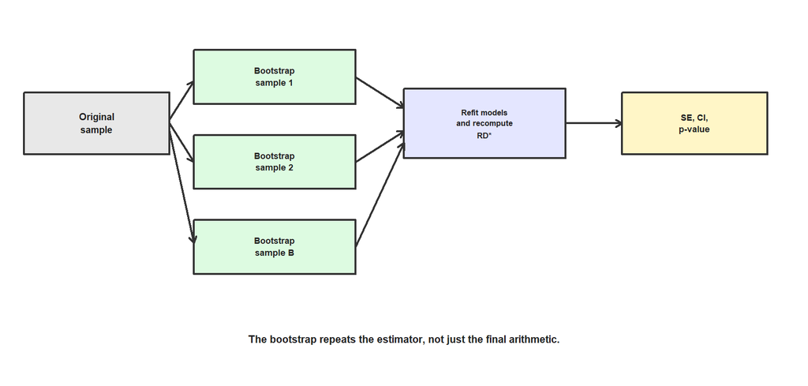

For this lecture note, we use `B = 300` bootstrap samples so the file can knit quickly. In a research project, it is common to use more, such as 1000 or 2000.

```r
set.seed(20260706)

B <- 300
n <- nrow(ht_data)

bootstrap_rd <- matrix(
  NA_real_,
  nrow = B,
  ncol = nrow(adjusted_estimates)
)

colnames(bootstrap_rd) <- rownames(adjusted_estimates)

for (b in seq_len(B)) {
  bootstrap_rows <- sample.int(n, size = n, replace = TRUE)
  bootstrap_data <- ht_data[bootstrap_rows, ]
  bootstrap_rd[b, ] <- safe_fit_adjusted_rd(bootstrap_data)
}

bootstrap_rd <- bootstrap_rd[complete.cases(bootstrap_rd), , drop = FALSE]

number_of_successful_bootstraps <- nrow(bootstrap_rd)
number_of_successful_bootstraps
```

```
## [1] 300
```

```r
bootstrap_se <- apply(bootstrap_rd, 2, sd)

bootstrap_ci <- t(apply(
  bootstrap_rd,
  2,
  quantile,
  probs = c(0.025, 0.975),
  na.rm = TRUE
))

colnames(bootstrap_ci) <- c("Lower", "Upper")

adjusted_rd <- adjusted_estimates[, "rd"]
z_adjusted <- adjusted_rd / bootstrap_se[rownames(adjusted_estimates)]
p_adjusted <- 2 * pnorm(-abs(z_adjusted))

adjusted_inference_table <- data.frame(
  Method = c("IPW", "Outcome regression", "Doubly robust"),
  Estimate_pp = round(100 * adjusted_rd, 2),
  Bootstrap_SE_pp = round(
    100 * bootstrap_se[rownames(adjusted_estimates)],
    2
  ),
  Z_statistic = round(z_adjusted, 2),
  P_value = signif(p_adjusted, 3),
  CI_lower_pp = round(100 * bootstrap_ci[, "Lower"], 2),
  CI_upper_pp = round(100 * bootstrap_ci[, "Upper"], 2),
  Conclusion_at_0_05 = ifelse(
    p_adjusted < 0.05,
    "Reject H0",
    "Do not reject H0"
  ),
  row.names = NULL
)

knitr::kable(
  adjusted_inference_table,
  col.names = c(
    "Method",
    "Estimate (pp)",
    "Bootstrap SE (pp)",
    "z",
    "p-value",
    "95% CI lower (pp)",
    "95% CI upper (pp)",
    "Conclusion at 0.05"
  )
)
```

| Method | Estimate (pp) | Bootstrap SE (pp) | z | p-value | 95% CI lower (pp) | 95% CI upper (pp) | Conclusion at 0.05 |
| --- | --- | --- | --- | --- | --- | --- | --- |
| IPW | 2.99 | 0.79 | 3.78 | 1.60e-04 | 1.36 | 4.55 | Reject H0 |
| Outcome regression | 3.45 | 0.78 | 4.43 | 9.50e-06 | 1.84 | 4.98 | Reject H0 |
| Doubly robust | 3.25 | 0.78 | 4.17 | 3.02e-05 | 1.69 | 4.78 | Reject H0 |

The bootstrap standard error measures how much the adjusted estimate moves when we repeatedly rebuild the full estimator in resampled datasets.

## 10 Compare All Tests

Now we place the crude analytic test and the three adjusted bootstrap tests in one table.

```r
combined_inference <- rbind(
  data.frame(
    Method = "Observed comparison",
    Estimate_pp = 100 * rd_crude,
    SE_pp = 100 * se_crude,
    Z_statistic = z_crude,
    P_value = p_crude,
    CI_lower_pp = 100 * ci_crude[1],
    CI_upper_pp = 100 * ci_crude[2],
    SE_source = "Two-sample proportion formula"
  ),
  data.frame(
    Method = c("IPW", "Outcome regression", "Doubly robust"),
    Estimate_pp = 100 * adjusted_rd,
    SE_pp = 100 * bootstrap_se[rownames(adjusted_estimates)],
    Z_statistic = z_adjusted,
    P_value = p_adjusted,
    CI_lower_pp = 100 * bootstrap_ci[, "Lower"],
    CI_upper_pp = 100 * bootstrap_ci[, "Upper"],
    SE_source = "Nonparametric bootstrap"
  )
)

combined_display <- combined_inference
combined_display$Estimate_pp <- round(combined_display$Estimate_pp, 2)
combined_display$SE_pp <- round(combined_display$SE_pp, 2)
combined_display$Z_statistic <- round(combined_display$Z_statistic, 2)
combined_display$P_value <- signif(combined_display$P_value, 3)
combined_display$CI_lower_pp <- round(combined_display$CI_lower_pp, 2)
combined_display$CI_upper_pp <- round(combined_display$CI_upper_pp, 2)

knitr::kable(
  combined_display,
  col.names = c(
    "Method",
    "Estimate (pp)",
    "SE (pp)",
    "z",
    "p-value",
    "95% CI lower (pp)",
    "95% CI upper (pp)",
    "SE source"
  )
)
```

|  | Method | Estimate (pp) | SE (pp) | z | p-value | 95% CI lower (pp) | 95% CI upper (pp) | SE source |
| --- | --- | --- | --- | --- | --- | --- | --- | --- |
| rd | Observed comparison | 8.20 | 0.82 | 9.99 | 0.00e+00 | 6.59 | 9.81 | Two-sample proportion formula |
| IPW | IPW | 2.99 | 0.79 | 3.78 | 1.60e-04 | 1.36 | 4.55 | Nonparametric bootstrap |
| Outcome_regression | Outcome regression | 3.45 | 0.78 | 4.43 | 9.50e-06 | 1.84 | 4.98 | Nonparametric bootstrap |
| Doubly_robust | Doubly robust | 3.25 | 0.78 | 4.17 | 3.02e-05 | 1.69 | 4.78 | Nonparametric bootstrap |

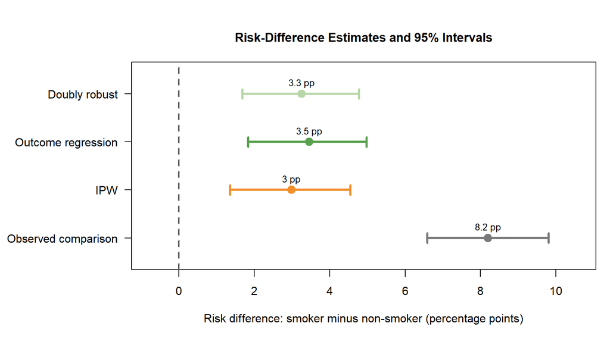

The vertical dashed line is $RD=0$, the null value. Estimates farther from zero relative to their standard errors produce larger absolute $z$-statistics and smaller p-values.

## 11 Interpreting the Results

The crude test and the adjusted tests can lead to different numbers because they estimate different contrasts.

The crude comparison tests:

$$P(Y=1 \mid T=1) - P(Y=1 \mid T=0) = 0.$$

The adjusted analyses test an identified causal contrast under the assumptions from Lectures 2-4:

$$E\{Y(1)\} - E\{Y(0)\} = 0.$$

Those two are the same only if the crude comparison is already unconfounded. In observational smoking data, that is usually not a comfortable assumption.

A small adjusted p-value means:

> Under the fitted adjustment strategy and its assumptions, the estimated adjusted risk difference is far from zero relative to its estimated sampling uncertainty.

It does **not** mean:

1. the null hypothesis is impossible;
2. the alternative hypothesis is true with probability $1-p$;
3. the effect is scientifically large;
4. the analysis is free from confounding, measurement error, missing-data bias, or model misspecification.

Conversely, a large p-value does not prove no effect. It may reflect a small effect, a noisy estimator, limited sample size, poor overlap, or an estimand whose standard error is large.

## 12 Link to Lecture 6

Lecture 6 asked a different question:

> How strong would unmeasured confounding have to be to explain away the result?

That is not the same as a p-value.

| Tool | Main question | What it does not solve |
| --- | --- | --- |
| p-value | Is the estimate far from the null relative to sampling uncertainty? | Unmeasured confounding |
| Confidence interval | What range of effect sizes is compatible with sampling uncertainty? | Bias from wrong assumptions |
| E-value | How strong would unmeasured confounding need to be on the risk-ratio scale? | Random sampling variability by itself |

So the course message is:

> Report statistical uncertainty and causal-validity concerns side by side.

The best causal report does not stop at “p < 0.05.” It states the estimand, method, confidence interval, p-value, and key assumptions.

## 13 One-Sided Tests

If the scientific question is directional, such as whether smoking increases CVD risk, the alternative can be written

$$H_A: RD > 0.$$

The one-sided p-value is

$$p_{\mathrm{one-sided}}
=
P\{N(0,1) \geq Z_{\mathrm{obs}}\}
=
1 - \Phi(Z_{\mathrm{obs}})$$

when large positive values are evidence against the null.

A one-sided test should be chosen before seeing the data. Switching from two-sided to one-sided after observing the estimate is not a valid way to reduce a p-value.

## 14 How to Report This Analysis

A concise classroom report should include:

1. **Estimand:** risk difference $E\{Y(1)\} - E\{Y(0)\}$.
2. **Method:** crude, IPW, outcome regression, or doubly robust.
3. **Estimate:** the risk difference in percentage points.
4. **Uncertainty:** standard error or 95 percent confidence interval.
5. **Test:** null value, test statistic, and p-value.
6. **Assumptions:** consistency, conditional exchangeability, positivity, and model adequacy.
7. **Sensitivity:** what Lecture 6 says about possible unmeasured confounding.

For example, a doubly robust result can be reported as follows.

```r
dr_report <- combined_inference[combined_inference$Method == "Doubly robust", ]

cat(
  "Using the doubly robust estimator, the adjusted risk difference was ",
  round(dr_report$Estimate_pp, 2),
  " percentage points, with a 95% interval from ",
  round(dr_report$CI_lower_pp, 2),
  " to ",
  round(dr_report$CI_upper_pp, 2),
  " percentage points and a two-sided p-value of ",
  signif(dr_report$P_value, 3),
  ".",
  sep = ""
)
```

```
## Using the doubly robust estimator, the adjusted risk difference was 3.25 percentage points, with a 95% interval from 1.69 to 4.78 percentage points and a two-sided p-value of 3.02e-05.
```

This sentence is only complete if it is followed by the causal assumptions and the sensitivity-analysis caveats.

## 15 Hypothesis Testing Checklist

Before interpreting a hypothesis test in this course, check the following:

1. **Estimand:** Is the test about a crude association or an adjusted causal estimand?
2. **Null value:** Is the null on the risk-difference, risk-ratio, odds-ratio, or another scale?
3. **Standard error:** Does the standard error correspond to the full estimator, including nuisance-model refitting when needed?
4. **Approximation:** Is the normal approximation reasonable, or is a bootstrap/randomization method being used?
5. **Identification:** Are consistency, exchangeability, and positivity plausible enough for a causal interpretation?
6. **Magnitude:** Is the estimated effect meaningful, not merely statistically detectable?
7. **Sensitivity:** What would happen under unmeasured confounding or different modeling choices?

## 16 Key Takeaways

1. Hypothesis testing comes after choosing an estimand and estimator.
2. A p-value measures compatibility with a null value under a statistical reference model.
3. For adjusted causal estimators, the bootstrap should repeat the full estimation procedure.
4. A confidence interval is often more useful than a p-value because it shows effect size and uncertainty.
5. Statistical significance does not prove causality; causal interpretation still depends on the assumptions from Lectures 1-4.
6. Lecture 6 sensitivity analysis answers a different question than hypothesis testing.

## 17 Appendix: Math of the Tests Used Here

This appendix collects the formulas behind the calculations in the main text.

### 17.1 Appendix 1: Observed Risk Difference

The observed risks are

$$\hat p_1
=
\frac{\sum_{i=1}^{n} T_iY_i}
{\sum_{i=1}^{n} T_i}$$

and

$$\hat p_0
=
\frac{\sum_{i=1}^{n} (1-T_i)Y_i}
{\sum_{i=1}^{n} (1-T_i)}.$$

The observed risk difference is

$$\widehat{RD}_{obs}
=
\hat p_1 - \hat p_0.$$

The standard error used in the Lecture 1-style test is

$$\widehat{SE}(\widehat{RD}_{obs})
=
\sqrt{
\frac{\hat p_1(1-\hat p_1)}{n_1}
+
\frac{\hat p_0(1-\hat p_0)}{n_0}
}.$$

### 17.2 Appendix 2: IPW Estimator

Let

$$e(X_i) = P(T_i = 1 \mid X_i)$$

be the propensity score.

The IPW risk under smoking is

$$\hat\psi_1^{IPW}
=
\frac{
\sum_{i=1}^{n}
\dfrac{T_iY_i}{\hat e(X_i)}
}{
\sum_{i=1}^{n}
\dfrac{T_i}{\hat e(X_i)}
}.$$

The IPW risk under non-smoking is

$$\hat\psi_0^{IPW}
=
\frac{
\sum_{i=1}^{n}
\dfrac{(1-T_i)Y_i}{1-\hat e(X_i)}
}{
\sum_{i=1}^{n}
\dfrac{1-T_i}{1-\hat e(X_i)}
}.$$

Then

$$\widehat{RD}^{IPW}
=
\hat\psi_1^{IPW} - \hat\psi_0^{IPW}.$$

### 17.3 Appendix 3: Outcome Regression Estimator

Let

$$m(t, X_i) = E(Y_i \mid T_i=t, X_i).$$

After fitting the outcome model, standardization estimates

$$\hat\psi_t^{OR}
=
\frac{1}{n}
\sum_{i=1}^{n}
\hat m(t, X_i),
\qquad t \in \{0,1\}.$$

The outcome-regression risk difference is

$$\widehat{RD}^{OR}
=
\hat\psi_1^{OR} - \hat\psi_0^{OR}.$$

### 17.4 Appendix 4: Doubly Robust Estimator

The doubly robust risk under smoking is

$$\hat\psi_1^{DR}
=
\frac{1}{n}
\sum_{i=1}^{n}
\left[
\hat m(1,X_i)
+
\frac{T_i}{\hat e(X_i)}
\{Y_i - \hat m(1,X_i)\}
\right].$$

The doubly robust risk under non-smoking is

$$\hat\psi_0^{DR}
=
\frac{1}{n}
\sum_{i=1}^{n}
\left[
\hat m(0,X_i)
+
\frac{1-T_i}{1-\hat e(X_i)}
\{Y_i - \hat m(0,X_i)\}
\right].$$

The doubly robust risk difference is

$$\widehat{RD}^{DR}
=
\hat\psi_1^{DR} - \hat\psi_0^{DR}.$$

### 17.5 Appendix 5: Bootstrap Standard Error

Let $\widehat{RD}^{*(1)}, \ldots, \widehat{RD}^{*(B)}$ be the bootstrap estimates.

The bootstrap standard error is

$$\widehat{SE}_{boot}
=
\sqrt{
\frac{1}{B-1}
\sum_{b=1}^{B}
\left(
\widehat{RD}^{*(b)}
-
\overline{RD}^{*}
\right)^2
},$$

where

$$\overline{RD}^{*}
=
\frac{1}{B}
\sum_{b=1}^{B}
\widehat{RD}^{*(b)}.$$

The Wald statistic using the bootstrap standard error is

$$Z_{boot}
=
\frac{\widehat{RD}}{\widehat{SE}_{boot}}$$

for testing $H_0: RD=0$.

### 17.6 Appendix 6: Percentile Bootstrap Confidence Interval

The percentile bootstrap 95 percent confidence interval is

$$\left[
Q_{0.025}\{\widehat{RD}^{*}\},
Q_{0.975}\{\widehat{RD}^{*}\}
\right],$$

where $Q_a\{\widehat{RD}^{*}\}$ is the $a$-quantile of the bootstrap estimates.

## 18 References

Austin, P. C., & Stuart, E. A. (2015). Moving towards best practice when using inverse probability of treatment weighting using the propensity score to estimate causal treatment effects in observational studies. *Statistics in Medicine*, 34(28), 3661-3679.

Cole, S. R., & Hernan, M. A. (2008). Constructing inverse probability weights for marginal structural models. *American Journal of Epidemiology*, 168(6), 656-664.

Efron, B., & Tibshirani, R. J. (1993). *An Introduction to the Bootstrap*. Chapman & Hall/CRC.

Hernan, M. A., & Robins, J. M. (2020). *Causal Inference: What If*. Chapman & Hall/CRC.

Imbens, G. W., & Rubin, D. B. (2015). *Causal Inference for Statistics, Social, and Biomedical Sciences: An Introduction*. Cambridge University Press.

van der Vaart, A. W. (1998). *Asymptotic Statistics*. Cambridge University Press.